# Homework 4 (Optional)

# Preliminaries

- This file should be in `STAT240/homework/hw04` on your local computer.
- You should also download `education.csv` and `obesity.csv` to `STAT240/data` on your local computer.

The end goal of this assignment is to compare the obesity percentage in each zip code and sex with the college educated percentage. Both dataframes contain data on Wisconsin residents.

# Problem 1

Every row of `education_original` represents a zip code within Wisconsin; a small-ish region that the Postal Office uses for mailing purposes.

`pct_f_bach` represents the percentage of female adults within that zip code that have a bachelor’s degree.

`pct_m_bach` represents the percentage of male adults within that zip code that have a bachelor’s degree.

```r
head(education_original)
```

```
## # A tibble: 6 × 3
##     zip pct_m_bach pct_f_bach
##   <dbl>      <dbl>      <dbl>
## 1 53001       13         23
## 2 53002       16.2       25.4
## 3 53003        6.8        9.4
## 4 53004       23.3       26.8
## 5 53005       55.6       53.9
## 6 53006       15.4       26.8
```

The following chunk is provided for you.

```r
# Do not edit this chunk!
education_original %>%
  summarize(w = n(),
            x = sum(pct_f_bach > pct_m_bach, na.rm = T),
            y = mean(pct_f_bach > pct_m_bach, na.rm = T),
            z = sum(is.na(pct_f_bach) & is.na(pct_m_bach)))
```

```
## # A tibble: 1 × 4
##       w     x     y     z
##   <int> <int> <dbl> <int>
## 1   776   596 0.771     3
```

What do each of these four quantities represent in real terms? Do not use technical vocabulary.

- `w` is the number of zip codes in Wisconsin.
- `x` is the number of zip codes in which the percentage of women with a bachelors degree is higher than the percentage of men with a bachelors degree.
- `y` is the percentage of zip codes in which the percentage of women with a bachelors degree is higher than the percentage of men with a bachelors degree.
- `z` is the number of zip codes in which both the percentage of women with a bachelors degree and the percentage of men with a bachelors degree are unknown.

# Problem 2

Using `education_original`, create a scatter plot with `pct_f_bach` on the x axis and `pct_m_bach` on the y axis. There will be one point for each zip code.

Incorporate the following customizations:

- Add a straight, diagonal, red line with `slope = 1` and `intercept = 0` using `geom_abline()`.
- Improve the x and y axis labels.

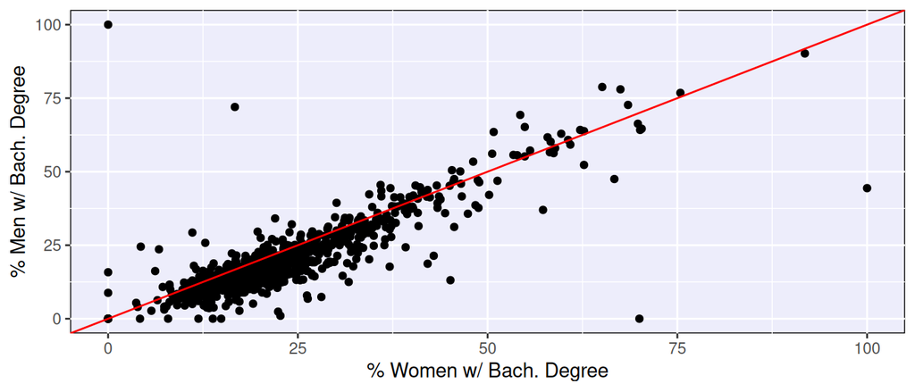

```r
ggplot(education_original, aes(pct_f_bach, pct_m_bach)) +
  geom_point() +
  geom_abline(color = "red", slope = 1, intercept = 0) +
  labs(
    x = "% Women w/ Bach. Degree",
    y = "% Men w/ Bach. Degree"
  )
```

What do points below this red line (e.g. the bottom/right half) represent in real terms?

Points below the red line represent a zip code in which the percentage of women with a bachelors degree is higher than the percentage of men with a bachelors degree.

# Problem 3

Our goal in this problem is to create a new dataframe called `education_long`. This dataframe will have the columns:

- `zip`
- `sex`: with values “female” and “male”
- `pct_bachelors`: The percentage of that sex within that zip code that has a bachelor’s degree.

Here are the first few rows of the dataframe we’re going for:

```
     zip sex    pct_bachelors
   <dbl> <chr>          <dbl>
 1 53001 male            13
 2 53001 female          23
 3 53002 male            16.2
 4 53002 female          25.4
```

The steps to generate this new dataframe are:

- Start with `education_original`.
- Drop any rows that have any missing data anywhere.
- Rename columns `pct_f_bach` and `pct_m_bach` to `female` and `male`.
- **Pivot** the dataframe to be **longer** such that you have TWO rows per zip code; one for each sex within zip.
- Make the column names after pivoting: `zip`, `sex`, and `pct_bachelors`.

```r
education_long <- education_original %>%
  drop_na() %>%
  rename(female = pct_f_bach, male = pct_m_bach) %>%
  pivot_longer(-zip, names_to = "sex", values_to = "pct_bachelors")
```

# Problem 4

Right now, the `obesity` data has one row for every zip-sex-age group combination; age groups are 5 years old - 17 years old, 18-34, 35-54, 55-74, and 75+.

We want to obtain a version of the `obesity` dataset we can merge with `education_long` above; so both datasets would have to have one row for every zip-sex combination.

This means we need to `summarize()` the obesity dataset to obtain one row per zip-sex combination, purposefully “smoothing over” all the age group detail we currently have.

The dataset we are trying to obtain will have the following first few rows:

```
     zip sex    total_pop total_obese_pop_estimate
   <dbl> <chr>      <dbl>                    <dbl>
 1 53001 female       726                     259.
 2 53001 male         755                     330.
 3 53002 female       977                     369.
 4 53002 male        1052                     404.
```

Create a new dataset called `obesity_summary` by executing the following steps:

- Start from `obesity`.
- Remove all rows with data about the youngest age group (05-17), since the `education_long` dataset is only about adults.
- Within each row, calculate `obese_percent` by taking `obese/n`. (`n` is the number of people we have data for; `pop` is the total population, so `obese/n` is just an estimate)
- Within each row, calculate `obese_pop_estimate` by taking `obese_percent * pop`.
- Group and summarize the data, such that you obtain one row per zip-sex combination (like in `education_long`), with the information:
  - Total population within that zip-sex combination: call this `total_pop`
  - Total obese population (estimated) within that zip-sex combination: call this `total_obese_pop_estimate`.
  - Note that you will have to use `na.rm = T` when summarizing to avoid NAs.
- Remove all rows where there are 0 estimated obese individuals. (*Bonus question: Why didn’t we just do this at the beginning? Answer at the bottom of the question.*)

```r
obesity_summary = obesity %>%
  filter(age != "05-17") %>%
  mutate(
    obese_percent = obese/n,
    obese_pop_estimate = obese_percent * pop
  ) %>%
  group_by(zip, sex) %>%
  summarize(
    total_pop = sum(pop, na.rm = T),
    total_obese_pop_estimate = sum(obese_pop_estimate, na.rm = T)
  ) %>%
  filter(total_obese_pop_estimate != 0)
```

Answer to bonus question: We needed to know the `pop` from every single row to calculate total population of a zip-sex combo, even if there were no obese people in that row. If we would have cleared out the 0 obese rows early, we would have lost some population.

# Problem 5

Create a new dataframe called `joined` by joining `education_long` and `obesity_summary` (note that their rows should match by `zip` and `sex` together) and only keeping rows that match in both dataframes.

Your first four rows of `joined` should look like this:

```
     zip sex    pct_bachelors total_pop total_obese_pop_estimate
   <dbl> <chr>          <dbl>     <dbl>                    <dbl>
 1 53001 male            13         755                     330.
 2 53001 female          23         726                     259.
 3 53002 male            16.2      1052                     404.
 4 53002 female          25.4       977                     369.
```

```r
joined <- inner_join(education_long, obesity_summary, join_by(zip, sex))
```

# Problem 6

Using `joined` from the previous problem, create a scatter plot of points with `pct_bachelors` on the x-axis and percentage obese on the y axis. You will have to calculate percentage obese for this problem.

Incorporate the following customizations:

- Color the points by sex.
- Improve the labels of the x axis, y axis, and legend.
- Add a single smooth line showing the trend of the data. (You should not have two different lines by sex!)

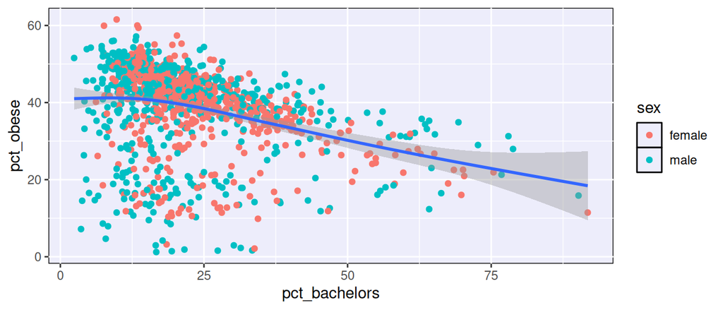

```r
joined %>%
  mutate(pct_obese = 100*total_obese_pop_estimate/total_pop) %>%
ggplot(aes(pct_bachelors, pct_obese)) +
  geom_point(aes(color = sex)) +
  geom_smooth()
```

What does this graph tell you about the relationship between college education rates and obesity rates?

As the percentage of adults with a bachelor’s degree goes up, the percentage of adults with obesity tends to decrease.

# Problem 7

Use `joined` to compute:

- The percentage of the entire Wisconsin adult population with a bachelor’s degree
- The percentage of the entire Wisconsin adult population with obesity

Let these values be printed as output.

```r
joined %>%
  mutate(num_bachelors = pct_bachelors * total_pop) %>%
  summarize(
    perc_bachelors = sum(num_bachelors)/sum(total_pop),
    perc_obese = sum(total_obese_pop_estimate)/sum(total_pop)
  )
```

```
## # A tibble: 1 × 2
##   perc_bachelors perc_obese
##            <dbl>      <dbl>
## 1           29.3      0.362
```

It is okay if one percentage is on the 0-1 scale and the other is on the 0-100 scale. You should get the following percentages:

```
  perc_bachelors perc_obese
           <dbl>      <dbl>
1           29.3      0.362
```

# Problem 8

```r
joined %>%
  mutate(num_bachelors = pct_bachelors * total_pop) %>%
  group_by(sex) %>%
  summarize(
    perc_bachelors = sum(num_bachelors)/sum(total_pop),
    perc_obese = sum(total_obese_pop_estimate)/sum(total_pop)
  )
```

```
## # A tibble: 2 × 3
##   sex    perc_bachelors perc_obese
##   <chr>           <dbl>      <dbl>
## 1 female           30.4      0.375
## 2 male             28.2      0.349
```

You should get the following output:

```
  sex    perc_bachelors perc_obese
  <chr>           <dbl>      <dbl>
1 female           30.4      0.375
2 male             28.2      0.349
```